# Group Assignment 1

Analytics for Strategy

Wahib Charamand, Valentin de la Pena, Jinwen Wu, Abe Rubin

```r
# Packages
library(multcomp)
library(sandwich)
library(ggplot2)
library(lmtest)
library(dplyr)

# Load Dataset
lunchsales <- read.csv("lunchsales-1.csv")
```

```r
### Regression Model - Lunch Sales

  # Build Regression Model
lunchsalesmodel <- lm(NumberOfLunchSales ~ PrecipitationMm + LunchtimeTemperatureCelsius + HumidityPct + HighSeason + NumberOfOpenCompetitors + as.factor(DayOfWeek), data = lunchsales)

  # Summarize Regression Model
summary(lunchsalesmodel)
```

```
##
## Call:
## lm(formula = NumberOfLunchSales ~ PrecipitationMm + LunchtimeTemperatureCelsius +
##     HumidityPct + HighSeason + NumberOfOpenCompetitors + as.factor(DayOfWeek),
##     data = lunchsales)
##
## Residuals:
##     Min      1Q  Median      3Q     Max
## -52.215 -12.179  -0.783  11.816  74.316
##
## Coefficients:
##                                Estimate Std. Error t value Pr(>|t|)
## (Intercept)                   174.28431   10.13405  17.198  < 2e-16 ***
## PrecipitationMm                -0.22751    0.07345  -3.097  0.00203 **
## LunchtimeTemperatureCelsius    -1.17651    0.14534  -8.095 2.53e-15 ***
## HumidityPct                    -0.41824    0.07795  -5.366 1.10e-07 ***
## HighSeason                      9.18171    1.96925   4.663 3.74e-06 ***
## NumberOfOpenCompetitors        -1.80049    0.38090  -4.727 2.75e-06 ***
## as.factor(DayOfWeek)Monday      1.92264    2.50380   0.768  0.44281
## as.factor(DayOfWeek)Saturday    2.19703    2.52311   0.871  0.38418
## as.factor(DayOfWeek)Sunday      6.56021    2.50981   2.614  0.00915 **
## as.factor(DayOfWeek)Thursday   -0.60137    2.47989  -0.243  0.80846
## as.factor(DayOfWeek)Tuesday     0.03326    2.50966   0.013  0.98943
## as.factor(DayOfWeek)Wednesday   3.88242    2.48848   1.560  0.11917
## ---
## Signif. codes:  0 '***' 0.001 '**' 0.01 '*' 0.05 '.' 0.1 ' ' 1
##
## Residual standard error: 17.82 on 703 degrees of freedom
## Multiple R-squared:  0.2162, Adjusted R-squared:  0.204
## F-statistic: 17.63 on 11 and 703 DF,  p-value: < 2.2e-16
```

```r
  # Use Heteroskedasticity-Robust Standard Errors
coeftest(lunchsalesmodel, vcovCL, type='HC1')
```

```
##
## t test of coefficients:
##
##                                 Estimate Std. Error t value  Pr(>|t|)
## (Intercept)                   174.284313  17.613513  9.8949 < 2.2e-16 ***
## PrecipitationMm                -0.227508   0.067036 -3.3938  0.000728 ***
## LunchtimeTemperatureCelsius    -1.176508   0.157097 -7.4891 2.085e-13 ***
## HumidityPct                    -0.418239   0.085298 -4.9033 1.172e-06 ***
## HighSeason                      9.181707   1.967646  4.6663 3.672e-06 ***
## NumberOfOpenCompetitors        -1.800485   1.251095 -1.4391  0.150559
## as.factor(DayOfWeek)Monday      1.922640   2.329235  0.8254  0.409403
## as.factor(DayOfWeek)Saturday    2.197032   2.620285  0.8385  0.402052
## as.factor(DayOfWeek)Sunday      6.560213   2.776890  2.3624  0.018427 *
## as.factor(DayOfWeek)Thursday   -0.601373   2.405185 -0.2500  0.802636
## as.factor(DayOfWeek)Tuesday     0.033258   2.322863  0.0143  0.988581
## as.factor(DayOfWeek)Wednesday   3.882416   2.409423  1.6113  0.107553
## ---
## Signif. codes:  0 '***' 0.001 '**' 0.01 '*' 0.05 '.' 0.1 ' ' 1
```

```r
### Regression Model - Log Lunch Sales

  # Check if Lunch Sales Are Ever 0
any(lunchsales$NumberOfLunches == 0)
```

```
## [1] FALSE
```

```r
  # (Above Returned False)

  # Create New Variable for Log Lunch Sales
lunchsales$LogLunchSales <- log(lunchsales$NumberOfLunchSales)

  # Build Regression Model
loglunchsalesmodel <- lm(LogLunchSales ~ PrecipitationMm + LunchtimeTemperatureCelsius + HumidityPct + HighSeason + NumberOfOpenCompetitors + as.factor(DayOfWeek), data = lunchsales)

  # Summarize Regression Model
summary(loglunchsalesmodel)
```

```
##
## Call:
## lm(formula = LogLunchSales ~ PrecipitationMm + LunchtimeTemperatureCelsius +
##     HumidityPct + HighSeason + NumberOfOpenCompetitors + as.factor(DayOfWeek),
##     data = lunchsales)
##
## Residuals:
##      Min       1Q   Median       3Q      Max
## -0.60324 -0.10871  0.00819  0.12374  0.71528
##
## Coefficients:
##                                 Estimate Std. Error t value Pr(>|t|)
## (Intercept)                    5.2618905  0.1004851  52.365  < 2e-16 ***
## PrecipitationMm               -0.0023633  0.0007283  -3.245  0.00123 **
## LunchtimeTemperatureCelsius   -0.0109379  0.0014412  -7.590 1.02e-13 ***
## HumidityPct                   -0.0039617  0.0007729  -5.126 3.84e-07 ***
## HighSeason                     0.1050068  0.0195263   5.378 1.03e-07 ***
## NumberOfOpenCompetitors       -0.0165261  0.0037768  -4.376 1.39e-05 ***
## as.factor(DayOfWeek)Monday     0.0272957  0.0248266   1.099  0.27195
## as.factor(DayOfWeek)Saturday   0.0217001  0.0250181   0.867  0.38603
## as.factor(DayOfWeek)Sunday     0.0576236  0.0248863   2.315  0.02087 *
## as.factor(DayOfWeek)Thursday  -0.0001688  0.0245895  -0.007  0.99452
## as.factor(DayOfWeek)Tuesday    0.0098900  0.0248847   0.397  0.69117
## as.factor(DayOfWeek)Wednesday  0.0430890  0.0246747   1.746  0.08120 .
## ---
## Signif. codes:  0 '***' 0.001 '**' 0.01 '*' 0.05 '.' 0.1 ' ' 1
##
## Residual standard error: 0.1767 on 703 degrees of freedom
## Multiple R-squared:  0.2137, Adjusted R-squared:  0.2013
## F-statistic: 17.36 on 11 and 703 DF,  p-value: < 2.2e-16
```

```r
  # Use Heteroskedasticity-Robust Standard Errors
coeftest(loglunchsalesmodel, vcovCL, type='HC1')
```

```
##
## t test of coefficients:
##
##                                  Estimate  Std. Error t value  Pr(>|t|)
## (Intercept)                    5.26189045  0.16907311 31.1220 < 2.2e-16 ***
## PrecipitationMm               -0.00236326  0.00072462 -3.2614  0.001162 **
## LunchtimeTemperatureCelsius   -0.01093794  0.00149531 -7.3148 7.045e-13 ***
## HumidityPct                   -0.00396166  0.00082806 -4.7843 2.092e-06 ***
## HighSeason                     0.10500683  0.02094736  5.0129 6.793e-07 ***
## NumberOfOpenCompetitors       -0.01652613  0.01204678 -1.3718  0.170554
## as.factor(DayOfWeek)Monday     0.02729566  0.02367031  1.1532  0.249237
## as.factor(DayOfWeek)Saturday   0.02170014  0.02711173  0.8004  0.423751
## as.factor(DayOfWeek)Sunday     0.05762356  0.02736788  2.1055  0.035600 *
## as.factor(DayOfWeek)Thursday  -0.00016885  0.02435637 -0.0069  0.994471
## as.factor(DayOfWeek)Tuesday    0.00989004  0.02403494  0.4115  0.680841
## as.factor(DayOfWeek)Wednesday  0.04308895  0.02425348  1.7766  0.076065 .
## ---
## Signif. codes:  0 '***' 0.001 '**' 0.01 '*' 0.05 '.' 0.1 ' ' 1
```

Question 1:

1. All else equal, a one store increase in the number of open competitors decreases lunch sales for the mom-and-pop restaurant by 1.80049 lunch orders. The sign on this coefficient does make sense, as one would expect the addition of a competitor on a given day to draw in customers, taking away customers from the mom-and-pop restaurant and, in turn, decreasing lunch sales.
2. All else equal, a one unit increase in the number of open competitors decreases lunch sales for the mom-and-pop restaurant by 1.65261%, all else being equal.
3. One clear omitted variable could be current economic conditions in the area surrounding the mom-and-pop store. Local economic conditions would likely be positively correlated with lunch sales, as diners would have more money to spend on not-necessities, such as going out for lunch as opposed to making it at home. Current economic conditions may also affect how many competitors are open on a given day, as more businesses may open in better economic conditions. Because local economic conditions are not included in our model, the coefficient on number of open competitors may be positively biased. The model may underestimate the effect of an additional open competitor because positive economic conditions drive both number of open competitors and sales higher.

Note: From here onward, we use the first model, lunch sales.

```r
### Test for Significance of Days of the Week

  # Note: Full Regression Was Created Above, Named "lunchsalesmodel"

  # Build Regression Model Without Day of the Week
lunchsalesmodel_t <- lm(NumberOfLunchSales ~ PrecipitationMm + LunchtimeTemperatureCelsius + HumidityPct + HighSeason + NumberOfOpenCompetitors, data = lunchsales)

  # Run Partial F-Test
anova(lunchsalesmodel, lunchsalesmodel_t)
```

```
## Analysis of Variance Table
##
## Model 1: NumberOfLunchSales ~ PrecipitationMm + LunchtimeTemperatureCelsius +
##     HumidityPct + HighSeason + NumberOfOpenCompetitors + as.factor(DayOfWeek)
## Model 2: NumberOfLunchSales ~ PrecipitationMm + LunchtimeTemperatureCelsius +
##     HumidityPct + HighSeason + NumberOfOpenCompetitors
##   Res.Df    RSS Df Sum of Sq      F  Pr(>F)
## 1    703 223195
## 2    709 227174 -6   -3978.6 2.0886 0.05253 .
## ---
## Signif. codes:  0 '***' 0.001 '**' 0.01 '*' 0.05 '.' 0.1 ' ' 1
```

```r
  # Change Baseline Category for Day of Week to Thursday
lunchsales$DayOfWeek <- relevel(factor(lunchsales$DayOfWeek), ref="Thursday")

  # Recreate Lunch Sales Model
lunchsalesmodel <- lm(NumberOfLunchSales ~ PrecipitationMm + LunchtimeTemperatureCelsius + HumidityPct + HighSeason + NumberOfOpenCompetitors + as.factor(DayOfWeek), data = lunchsales)

  # Summarize Updated Lunch Sales Model
summary(lunchsalesmodel)
```

```
##
## Call:
## lm(formula = NumberOfLunchSales ~ PrecipitationMm + LunchtimeTemperatureCelsius +
##     HumidityPct + HighSeason + NumberOfOpenCompetitors + as.factor(DayOfWeek),
##     data = lunchsales)
##
## Residuals:
##     Min      1Q  Median      3Q     Max
## -52.215 -12.179  -0.783  11.816  74.316
##
## Coefficients:
##                                Estimate Std. Error t value Pr(>|t|)
## (Intercept)                   173.68294   10.09050  17.213  < 2e-16 ***
## PrecipitationMm                -0.22751    0.07345  -3.097  0.00203 **
## LunchtimeTemperatureCelsius    -1.17651    0.14534  -8.095 2.53e-15 ***
## HumidityPct                    -0.41824    0.07795  -5.366 1.10e-07 ***
## HighSeason                      9.18171    1.96925   4.663 3.74e-06 ***
## NumberOfOpenCompetitors        -1.80049    0.38090  -4.727 2.75e-06 ***
## as.factor(DayOfWeek)Friday      0.60137    2.47989   0.243  0.80846
## as.factor(DayOfWeek)Monday      2.52401    2.47277   1.021  0.30774
## as.factor(DayOfWeek)Saturday    2.79840    2.49836   1.120  0.26306
## as.factor(DayOfWeek)Sunday      7.16159    2.47951   2.888  0.00399 **
## as.factor(DayOfWeek)Tuesday     0.63463    2.48370   0.256  0.79840
## as.factor(DayOfWeek)Wednesday   4.48379    2.46160   1.821  0.06896 .
## ---
## Signif. codes:  0 '***' 0.001 '**' 0.01 '*' 0.05 '.' 0.1 ' ' 1
##
## Residual standard error: 17.82 on 703 degrees of freedom
## Multiple R-squared:  0.2162, Adjusted R-squared:  0.204
## F-statistic: 17.63 on 11 and 703 DF,  p-value: < 2.2e-16
```

Question 2:

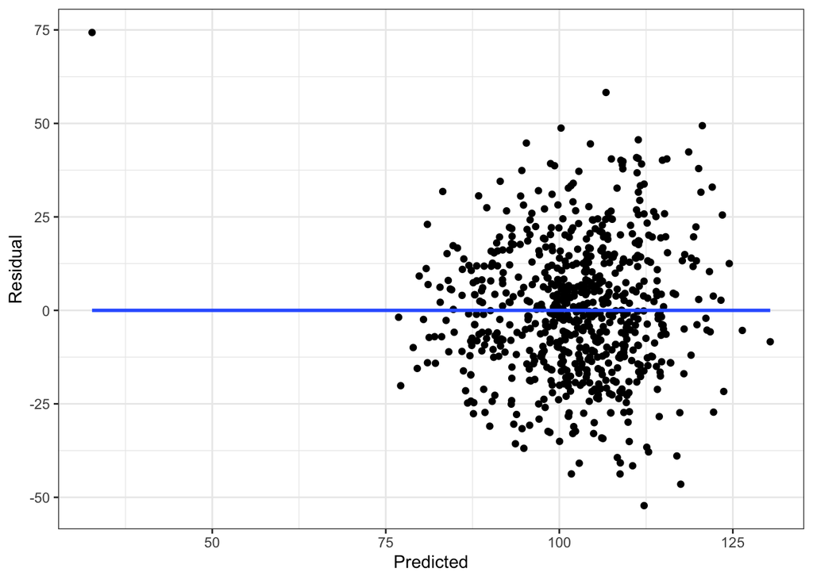

```r
### Residual Analysis

  # Gather Residuals
resid = lunchsalesmodel$residuals

  # Gather Predicted Values
predicted = fitted(lunchsalesmodel)

  # Graph Residuals and Predicted Values
residual_analysis <- data.frame(resid, predicted)
ggplot(residual_analysis, aes(x=predicted, y=resid)) +
  geom_point()+
  geom_smooth(method=lm, se=FALSE)+
  xlab("Predicted")+
  ylab("Residual")+
  theme_bw()
```

Question 3:

1. The plot reveals the existence of at least one relevant outlier where the model predicted very far off from the actual number of lunch sales on that day. Presumably, this day was one that does not have many of the characteristics of a high sales day, however, still sold a large number of lunches. Perhaps it was a holiday or otherwise special day that drove business high and, resultantly, was an outlier in the data.
2. To fix the issue above, we could simply eliminate the outlier from the dataset based on relevant characteristics. The result would likely increase the estimated effects of competition on sales, as the outlier represents a day with high sales and (likely) extensive competition, so, removing it would remove a point taking away from the negative relationship between competition and sales.

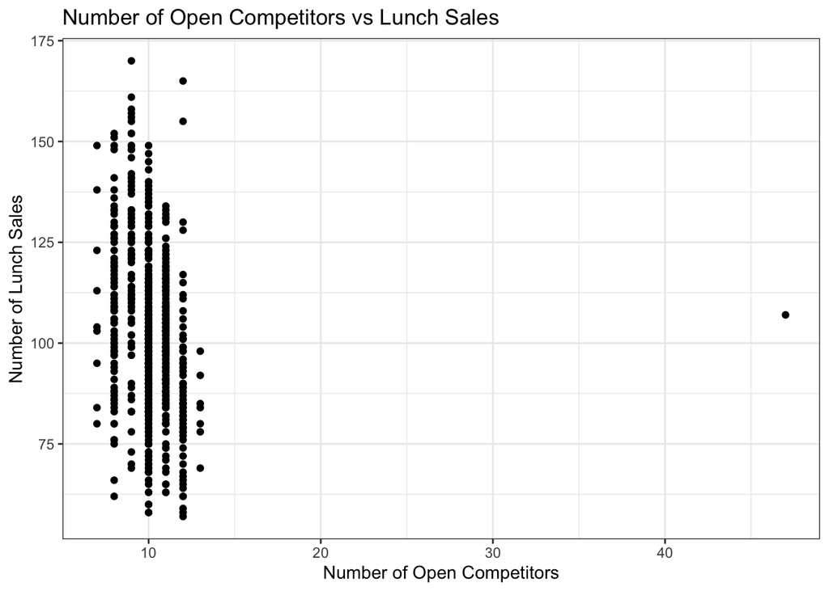

```r
### Test Hypothesis on Outlier

  # Create Scatterplot of Number of Lunch Sales and Number of Open Competitors
ggplot(lunchsales, aes(x = NumberOfOpenCompetitors, y = NumberOfLunchSales)) +
  geom_point() +
  theme_bw() +
  labs(title = "Number of Open Competitors vs Lunch Sales",
       x = "Number of Open Competitors",
       y = "Number of Lunch Sales")
```

Indeed, examining a scatterplot of lunch sales and open competitors reveals an outlier in which the store sold an average number of lunches with many competitors open. This looks like it may be an error in the data, as on no other days were there nearly as many competitors open.

```r
### Examine Results Without Outlier

  # Filter Data to Remove Outlier
lunchsales_no_outlier <- lunchsales %>%
  filter(NumberOfOpenCompetitors != 47)

  # (The Following Code is Copied from Previously to Test the Models Without the Outlier)

  # Build Regression Model
lunchsalesmodel <- lm(NumberOfLunchSales ~ PrecipitationMm + LunchtimeTemperatureCelsius + HumidityPct + HighSeason + NumberOfOpenCompetitors + as.factor(DayOfWeek), data = lunchsales_no_outlier)

  # Summarize Regression Model
summary(lunchsalesmodel)
```

```
##
## Call:
## lm(formula = NumberOfLunchSales ~ PrecipitationMm + LunchtimeTemperatureCelsius +
##     HumidityPct + HighSeason + NumberOfOpenCompetitors + as.factor(DayOfWeek),
##     data = lunchsales_no_outlier)
##
## Residuals:
##     Min      1Q  Median      3Q     Max
## -52.022 -11.469  -0.172  10.888  62.907
##
## Coefficients:
##                                Estimate Std. Error t value Pr(>|t|)
## (Intercept)                   209.08266   11.08136  18.868  < 2e-16 ***
## PrecipitationMm                -0.20429    0.07128  -2.866  0.00428 **
## LunchtimeTemperatureCelsius    -1.16084    0.14091  -8.238 8.54e-16 ***
## HumidityPct                    -0.47931    0.07609  -6.299 5.28e-10 ***
## HighSeason                      8.05477    1.91604   4.204 2.96e-05 ***
## NumberOfOpenCompetitors        -4.82419    0.57814  -8.344 3.79e-16 ***
## as.factor(DayOfWeek)Friday      0.76401    2.40394   0.318  0.75072
## as.factor(DayOfWeek)Monday      2.59123    2.39695   1.081  0.28004
## as.factor(DayOfWeek)Saturday    2.86398    2.42175   1.183  0.23737
## as.factor(DayOfWeek)Sunday      7.22976    2.40349   3.008  0.00272 **
## as.factor(DayOfWeek)Tuesday     0.56522    2.40754   0.235  0.81446
## as.factor(DayOfWeek)Wednesday   3.72817    2.38869   1.561  0.11903
## ---
## Signif. codes:  0 '***' 0.001 '**' 0.01 '*' 0.05 '.' 0.1 ' ' 1
##
## Residual standard error: 17.27 on 702 degrees of freedom
## Multiple R-squared:  0.2646, Adjusted R-squared:  0.253
## F-statistic: 22.96 on 11 and 702 DF,  p-value: < 2.2e-16
```

```r
  # Use Heteroskedasticity-Robust Standard Errors
coeftest(lunchsalesmodel, vcovCL, type='HC1')
```

```
##
## t test of coefficients:
##
##                                 Estimate Std. Error t value  Pr(>|t|)
## (Intercept)                   209.082663  11.146072 18.7584 < 2.2e-16 ***
## PrecipitationMm                -0.204289   0.063573 -3.2135  0.001371 **
## LunchtimeTemperatureCelsius    -1.160843   0.151806 -7.6469 6.795e-14 ***
## HumidityPct                    -0.479307   0.079801 -6.0063 3.046e-09 ***
## HighSeason                      8.054765   1.874932  4.2960 1.984e-05 ***
## NumberOfOpenCompetitors        -4.824189   0.599112 -8.0522 3.482e-15 ***
## as.factor(DayOfWeek)Friday      0.764011   2.352951  0.3247  0.745502
## as.factor(DayOfWeek)Monday      2.591232   2.237523  1.1581  0.247225
## as.factor(DayOfWeek)Saturday    2.863983   2.519005  1.1370  0.255947
## as.factor(DayOfWeek)Sunday      7.229762   2.646460  2.7319  0.006456 **
## as.factor(DayOfWeek)Tuesday     0.565218   2.216300  0.2550  0.798776
## as.factor(DayOfWeek)Wednesday   3.728168   2.277895  1.6367  0.102147
## ---
## Signif. codes:  0 '***' 0.001 '**' 0.01 '*' 0.05 '.' 0.1 ' ' 1
```

```r
  # Build Regression Model
loglunchsalesmodel <- lm(LogLunchSales ~ PrecipitationMm + LunchtimeTemperatureCelsius + HumidityPct + HighSeason + NumberOfOpenCompetitors + as.factor(DayOfWeek), data = lunchsales_no_outlier)

  # Summarize Regression Model
summary(loglunchsalesmodel)
```

```
##
## Call:
## lm(formula = LogLunchSales ~ PrecipitationMm + LunchtimeTemperatureCelsius +
##     HumidityPct + HighSeason + NumberOfOpenCompetitors + as.factor(DayOfWeek),
##     data = lunchsales_no_outlier)
##
## Residuals:
##      Min       1Q   Median       3Q      Max
## -0.60138 -0.10199  0.01329  0.11752  0.48891
##
## Coefficients:
##                                 Estimate Std. Error t value Pr(>|t|)
## (Intercept)                    5.6024399  0.1100869  50.891  < 2e-16 ***
## PrecipitationMm               -0.0021398  0.0007081  -3.022   0.0026 **
## LunchtimeTemperatureCelsius   -0.0107872  0.0013998  -7.706 4.43e-14 ***
## HumidityPct                   -0.0045494  0.0007559  -6.019 2.83e-09 ***
## HighSeason                     0.0941601  0.0190347   4.947 9.45e-07 ***
## NumberOfOpenCompetitors       -0.0456289  0.0057435  -7.944 7.76e-15 ***
## as.factor(DayOfWeek)Friday     0.0017342  0.0238818   0.073   0.9421
## as.factor(DayOfWeek)Monday     0.0281115  0.0238123   1.181   0.2382
## as.factor(DayOfWeek)Saturday   0.0225002  0.0240587   0.935   0.3500
## as.factor(DayOfWeek)Sunday     0.0584486  0.0238772   2.448   0.0146 *
## as.factor(DayOfWeek)Tuesday    0.0093908  0.0239175   0.393   0.6947
## as.factor(DayOfWeek)Wednesday  0.0359850  0.0237302   1.516   0.1299
## ---
## Signif. codes:  0 '***' 0.001 '**' 0.01 '*' 0.05 '.' 0.1 ' ' 1
##
## Residual standard error: 0.1716 on 702 degrees of freedom
## Multiple R-squared:  0.2593, Adjusted R-squared:  0.2477
## F-statistic: 22.34 on 11 and 702 DF,  p-value: < 2.2e-16
```

```r
  # Use Heteroskedasticity-Robust Standard Errors
coeftest(loglunchsalesmodel, vcovCL, type='HC1')
```

```
##
## t test of coefficients:
##
##                                  Estimate  Std. Error t value  Pr(>|t|)
## (Intercept)                    5.60243994  0.10594726 52.8795 < 2.2e-16 ***
## PrecipitationMm               -0.00213977  0.00068742 -3.1127  0.001929 **
## LunchtimeTemperatureCelsius   -0.01078716  0.00144821 -7.4486 2.776e-13 ***
## HumidityPct                   -0.00454944  0.00077421 -5.8763 6.482e-09 ***
## HighSeason                     0.09416014  0.01994953  4.7199 2.849e-06 ***
## NumberOfOpenCompetitors       -0.04562894  0.00582004 -7.8400 1.676e-14 ***
## as.factor(DayOfWeek)Friday     0.00173422  0.02384758  0.0727  0.942049
## as.factor(DayOfWeek)Monday     0.02811148  0.02178687  1.2903  0.197373
## as.factor(DayOfWeek)Saturday   0.02250017  0.02541703  0.8852  0.376330
## as.factor(DayOfWeek)Sunday     0.05844860  0.02533218  2.3073  0.021329 *
## as.factor(DayOfWeek)Tuesday    0.00939080  0.02213285  0.4243  0.671483
## as.factor(DayOfWeek)Wednesday  0.03598503  0.02207830  1.6299  0.103575
## ---
## Signif. codes:  0 '***' 0.001 '**' 0.01 '*' 0.05 '.' 0.1 ' ' 1
```

Repeating the initial model without the outlier yields a statistically significant coefficient of -4.82419 for the of number of open competitors on lunch sales and a statistically significant coefficient of -0.0456289 for the log effect of number of open competitors on lunch sales. These are both stronger than the coefficients we found when running the regression with the outlier included, in line with our expectations.